# Negative Binomial Simulation Study

Susanna Makela

September 19, 2016

We’re using the negative binomial to model the distribution of cluster sizes for unsampled clusters. How well does it actually predict the missing sizes under PPS sampling? This is a small simulation study to find out.

Note to self: add bibliography and Patil/Rao citation.

Let’s first simulate a population of clusters and see how well Stan can recover the true population parameters and simulate the nonsampled cluster sizes.

```r
library(ggplot2)
library(rstan)
library(shinystan)
source("src/rspps.r")
source("src/negbin_sim.R")
J <- 100 # number of clusters in pop
K <- 10 # number of clusters to sample
k <- 200
p <- 0.2
Nj.pop <- rnbinom(n = J, size = k, prob = p)
m <- (1 - p) * k / p
v <- (1 - p) * k / p^2
stan.model <- stan_model(file = "src/negbin.stan")
n.iter <- 1000
n.chains <- 4
n.sims <- 500
sim.res <- negbin_sim(Nj.pop, J, K, stan.model, n.iter, n.chains, n.sims)
```

[output not shown]

[output not shown]

[output not shown]

[output not shown]

[output not shown]

[output not shown]

[output not shown]

[output not shown]

[output not shown]

[output not shown]

[output not shown]

[output not shown]

[output not shown]

[output not shown]

[output not shown]

[output not shown]

[output not shown]

[output not shown]

[output not shown]

[output not shown]

[output not shown]

[output not shown]

[output not shown]

[output not shown]

```
## ############################################### Stan results ###############################################
##              mean se_mean   sd     2.5%      25%      50%      75%
## phi        224.06    0.26 9.56   205.80   217.11   224.03   230.87
## mu         787.13    0.23 8.49   769.51   781.51   787.25   792.54
## mu_star    790.64    0.23 8.53   773.04   785.02   790.80   796.09
## phi_star   225.06    0.26 9.56   206.80   218.11   225.03   231.87
## k          224.06    0.26 9.56   205.80   217.11   224.03   230.87
## p            0.22    0.00 0.01     0.21     0.22     0.22     0.23
## lp__     44708.70    0.03 0.95 44706.13 44708.36 44708.99 44709.36
##             97.5%   n_eff Rhat
## phi        242.83 1312.23    1
## mu         804.56 1327.22    1
## mu_star    808.01 1328.93    1
## phi_star   243.83 1312.23    1
## k          242.83 1312.23    1
## p            0.24 1335.84    1
## lp__     44709.59 1260.54    1
```

Here’s a histogram of the cluster sizes:

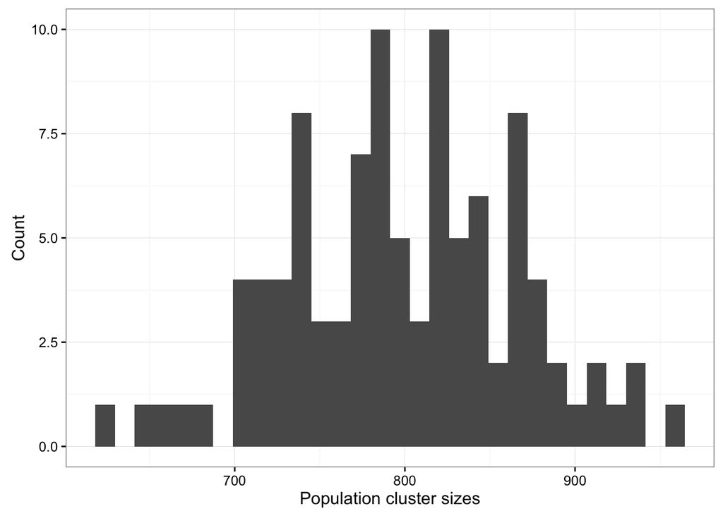

Here’s the stan model we fit to our data:

```
data {
  int JminusK;
  int K;
  int Nj_sample[K];
  real mu_empirical;
  real phi_empirical;
}
parameters {
  real<lower=0> phi;
  real<lower=0> mu;
}
transformed parameters {
  real<lower=0> mu_star;
  real<lower=0> phi_star;
  real<lower=0> k;
  real<lower=0> p;

  k = phi;
  p = phi / (phi + mu);

  phi_star = k + 1;
  mu_star = (k + 1) * (1 - p) / p;
}
model {
  mu ~ normal(mu_empirical, 10);
  phi ~ normal(phi_empirical, 10);
  Nj_sample ~ neg_binomial_2(mu_star, phi_star);
}
```

Let’s make a density plot of the nonsampled cluster sizes and see how the posterior predictive samples compare.

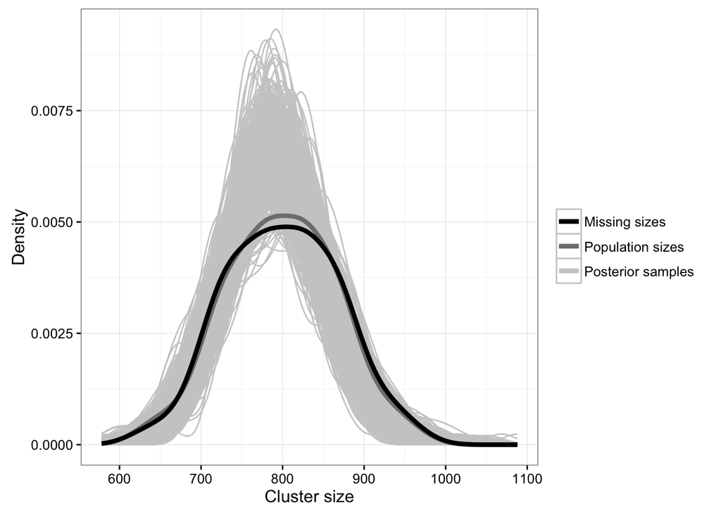

```r
# Plot density of true nonsampled cluster sizes vs the simulated ones
Nj.sims <- sim.res[["Nj.sims"]]
ggplot(Nj.sims, aes(x = Nj)) +
  geom_line(stat = "density", aes(group = simno, colour = "Posterior samples")) +
  geom_line(data = pop.data, aes(x = Nj.pop, colour = "Population sizes"),
            stat = "density", size = 1.5) +
  geom_line(data = Nj.sims[Nj.sims$simno == 0, ],
            aes(x = Nj, colour = "Missing sizes"), stat = "density", size = 1.5) +
  scale_colour_manual("",
                      values = c("Posterior samples" = "grey80",
                                 "Population sizes" = "grey50",
                                 "Missing sizes" = "black")) +
  xlab("Cluster size") +
  ylab("Density") +
  theme_bw()
```

The densities seem reasonably well-matched. Let’s see how well the model captures the min, max, mean, median, and quartiles of the nonsampled cluster sizes.

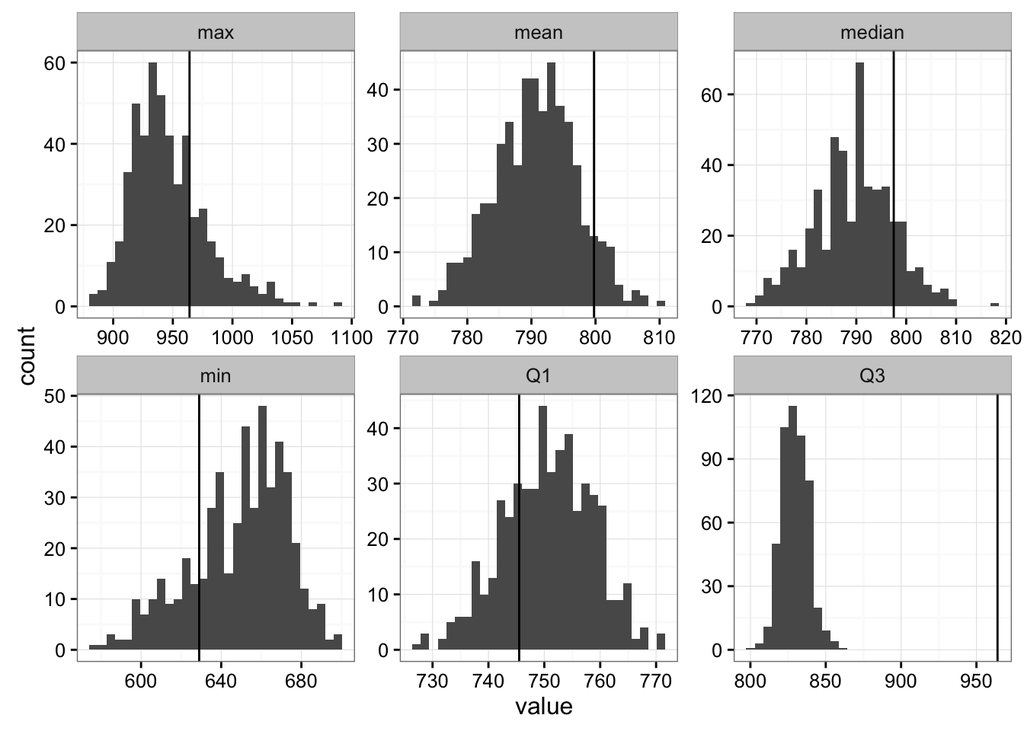

```
## # A tibble: 6 x 2
##     stat p_value
##   <fctr>   <dbl>
## 1    max   0.230
## 2   mean   0.084
## 3 median   0.136
## 4    min   0.800
## 5     Q1   0.744
## 6     Q3   0.000
```

Hmm… this was just one simulation. How do we know that the results we’re seeing aren’t a result of the cluster sizes we happened to draw? Let’s repeat the above simulation many times and see what the *distribution* of posterior p-values looks like.

Here’s the distribution of posterior p-values:

```
## # A tibble: 6 x 2
##     stat mean_pval
##   <fctr>     <dbl>
## 1    max   0.62938
## 2   mean   0.71714
## 3 median   0.70060
## 4    min   0.68162
## 5     Q1   0.73490
## 6     Q3   0.01004
```

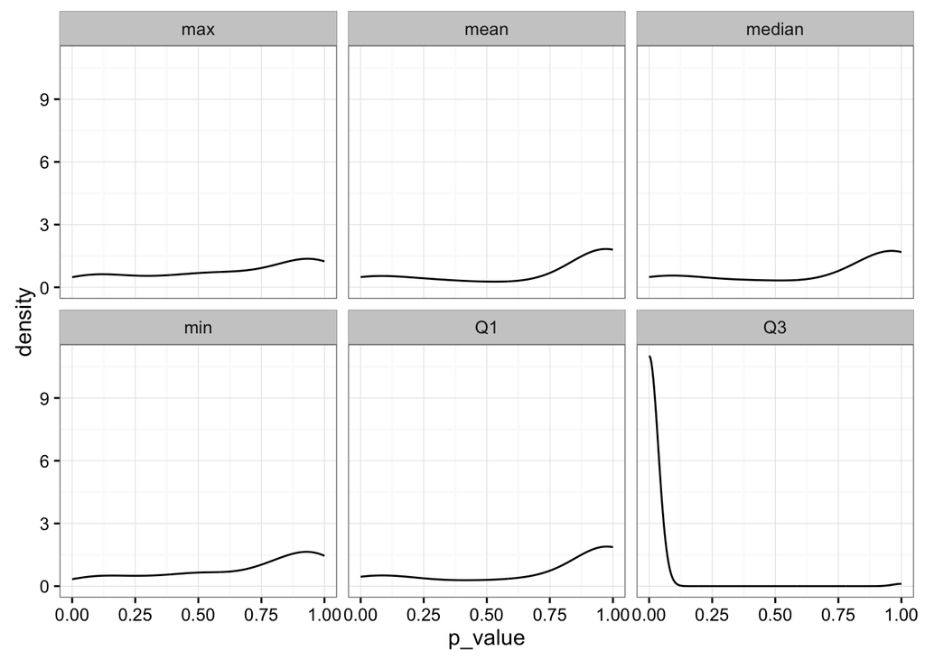

What if the cluster sizes had instead come from a lognormal distribution? What would things look like then?